# Predicción de Número de Hijos en un Hogar Colombiano con un Modelo KNN

El número de hijos en un hogar suele ser una variable importante en diferentes programas sociales, en el sector comercial al momento de ofrecer productos y en el sector financiero. Por ejemplo, un banco puede incluir el número de hijos en el hogar, en conjunto con otras variables, para determinar si ofrecer un crédito o no, puesto que entre más hijos haya en el hogar, más gastos conlleva.

Con esta motivación, proponemos un modelo capaz de predecir el número de hijos de los hogares colombianos a partir de diferentes características del hogar que suelen ser conocidas con mayor facilidad por las compañías que lo usen.

Para esto, usamos los datos dispuestos por el DANE en el Archivo Nacional de Datos [1] sobre la Encuesta Nacional de Calidad de Vida del 2019 como datos de entrenamiento y prueba del modelo.

# Retos

Los principales retos que afrontamos, fueron:

- Encontrar en la bibliografía disponible acerca de las familias colombianas, los principales factores que influyen en la fecundidad y el tamaño de la familia colombiana.
- Teniendo en cuenta las variables encontradas en la bibliografía, construirlas a partir de la encuesta dispuesta por el DANE.
- Preprocesar, filtrar y analizar los datos. i.e. Omitir las variables innecesarias, tratamiento de los valores nulos y un análisis descriptivo.
- Minimizar la cantidad de variables de entrada sin comprometer la precisión.

# Selección y Generación de las Variables de Entrada y Salida

Tras explorar la bibliografía, encontramos potenciales variables de entrada para el modelo:

- La `edad` y el `estado civil` son factores importantes, pues en Colombia cada vez más mujeres se casan a una mayor edad, una característica de la segunda transición demográfica; la cual también implica una posible caída en el nivel de fecundidad [2].
- El `nivel educativo`, en especial el nivel educativo de la mujer según [3] sugiere una disminución de la fertilidad de un país.
- El `ingreso mensual total del hogar` es otra característica importante, como señalado por [4], las mujeres que más se participaron económicamente son aquellas con niños entre 6 y 17 años. Así mismo, decidimos seleccionar el `estrato` como otro indicador relacionado con los ingresos.
- Así mismo, decidimos escoger algunas variables por nuestro criterio. La región y la etnia son variables que creímos importantes, pues como [2] expone, la región caribe es la más “retrasada” en separación de la sexualidad y la procreación, mientras que Medellín es la más “avanzada” en este aspecto, con respecto a la segunda transición demográfica. Además, la cantidad del personas en el hogar es una gran pista a cuántos hijos hacen parte del hogar.

## Importe de Librerías

Importamos las librerías necesarias para hacer el tratamiento inicial de los datos y la generación de la variable salida.

```r
library(dplyr)
library(tibble)
```

## Lectura de Datos

Leemos los datos que se encuentran en la carpeta `./data`, los cuales corresponden a los CSV dispuestos por el DANE en la Encuesta de Calidad de Vida del 2019.

```r
# Todos los nombres de los archivos .csv en el directorio `/data`
# precedido por el directorio.

file_paths <-
  list.files(path = '../data',
             pattern = '*.csv',
             full.names = TRUE)

# Todos los nombres de los archivos .csv en el directorio `/data`.

file_names <-
  list.files(path = '../data',
             pattern = '*.csv')

# Importa todos los archivos de la lista `file_paths`
# y los almacena en la lista `files`.

files <- lapply(
  file_paths,
  read.table,
  header = TRUE,
  sep = ';',
  dec = ','
)
```

## Caracterización de Capítulos (Tablas) de la Base de Datos

La base de datos de la encuesta está compuesta por diferentes tablas, las cuales están enfocadas a diferentes públicos de acuerdo a lo que se esté encuestando. Para entender mejor, el DANE define las unidades de observación *vivienda, hogar y persona*:

Una *vivienda* corresponde a un lugar físico donde viven las personas y en la que puede existir más de un *hogar*, ya que por ejemplo, pueden haber viviendas multifamiliares. Por último, en un *hogar* hay una o más *personas*.

Para poder unir las tablas, existen variables que se usan como llaves. Así:

- En las tablas de *vivienda*, la variable **DIRECTORIO** es el identificador único de cada vivienda.
- En las tablas de *hogar*, la variable **DIRECTORIO** identifica la vivienda donde se encuentra este hogar y la variable **SECUENCIA_ENCUESTA** indica el número del hogar dentro de esta vivienda.
- En las tablas de *persona*, **DIRECTORIO** indica la vivienda donde reside, la variable **SECUENCIA_P** indica el hogar al que pertenece y la variable **SECUENCIA_ENCUESTA** indica el número de la persona dentro del hogar.

Ahora veamos la caracterización de las tablas de la base de datos según los metadatos expuestos por el DANE:

| Tabla | Público encuestado |
| --- | --- |
| Datos de la vivienda | Vivienda |
| Servicios del hogar | Hogar |
| Características y composición del hogar | Persona |
| Salud | Persona |
| Atención integral de los niños y niñas menores de 5 años | Persona, edad < 5 |
| Educación | Persona, edad > 5 |
| Fuerza de trabajo | Persona, edad > 12 |
| Tecnologías de información y comunicación | Persona, edad > 5 |
| Trabajo infantil | Persona, 5 < edad < 11 |
| Tenencia y financiación de la vivienda que ocupa el hogar | Hogar |
| Condiciones de vida del hogar y tenencia de bienes | Hogar |
| Uso de energéticos del hogar | Hogar |

Sabiendo los identificadores de cada unidad de observación y la caracterización de las tablas, podemos notar que se encuestaron:

- $93.161$ viviendas.
- $93.993$ hogares.
- $289.558$ personas.

## Generación de la Etiqueta

En las tablas de hogar no hay una variable que indique el número de hijos en este, por lo que es necesario definir las condiciones en las que reconoceremos un hijo en el hogar, para así computarla.

Solo consideramos los **hijos de la cabeza de hogar**, por lo que no tendremos en cuenta los hijos de sus hijos (nietos) o cualquier otro escenario.

Con esta condición, podemos explorar la tabla *Características y composición del hogar*, donde la variable **P6051** indica el parentesco de la persona encuestada con el jefe de hogar. Los posibles valores de esta variable son:

- 1 Jefe (a) del hogar
- 2 Pareja, esposo (a), cónyuge, compañero(a)
- 3 Hijo(a) hijastro(a)
- 4 Nieto (a)
- 5 Padre, madre, padrastro y madrastra
- 6 Suegro o suegra
- 7 Hermano (a), hermanastro (a)
- 8 Yerno, nuera
- 9 Otro pariente del jefe(a)
- 10 Empleado(a) del servicio doméstico
- 11 Parientes del servicio doméstico
- 12 Trabajador
- 13 Pensionista
- 14 Otro pariente

Cuando esta variable es $3$, significa que la persona es un hijo del jefe de hogar. Por lo tanto, podemos computar cuántos hijos hay en un hogar contando el número de ocurrencias del valor $3$ en esta variable y agruparlo por hogar.

El procedimiento es un poco distinto a lo descrito anteriormente, pero la idea es la misma. Este puede verse a continuación:

1. Ya que solo nos interesan cuando el valor de la variable es $3$, cambiamos los valores de esta de tal manera que podamos sumarla por cada hogar. Reemplazamos entonces los valores de la siguiente manera:

$$\begin{cases}
1 & \text{cuando } P6051 = 3 \\
0 & \text{en otro caso }
\end{cases}$$
2. Agrupamos por hogar. Recordemos que las variables *DIRECTORIO* y *SECUENCIA_P* identifican un hogar en las tablas donde el público encuestado son todas las personas.

```r
# Trae la tabla de Características y composición del hogar
# donde se encuentra la variable P6051.
carac_persona <- files[[2]]

# Hacemos el reemplazo de la variable según el paso 1: (mutate, if_else)
# Agrupamos por las llaves del hogar en esta tabla (group_by)
# Generamos la variable HIJOS como la suma de P6051 (summarise, sum).
labeled <-
  carac_persona %>% mutate(P6051 = if_else(P6051 == 3, 1, 0)) %>% group_by(ï..DIRECTORIO, SECUENCIA_P) %>% summarise(HIJOS = sum(P6051), .groups = "keep")
```

## Selección de las Variables de Entrada

En el análisis descriptivo presentado más adelante, veremos qué variables están correlacionadas con la variable salida generada *HIJOS*.

Seleccionamos las siguientes variables de la base de datos:

| Tabla | Variable | Etiqueta | Tipo | Formato |
| --- | --- | --- | --- | --- |
| Características y composición del hogar | P6020 | Sexo | Discreta | Numérica |
| Características y composición del hogar | P6040 | Edad | Discreta | Numérica |
| Característiicas y composición del hogar | P5502 | Estado civil | Discreta | Numérica |
| Característiicas y composición del hogar | P6080 | Pueblo o etnia | Discreta | Numérica |
| Educación | P8587 | Nivel educativo | Discreta | Numérica |
| Datos de la vivienda | REGION | Región | Discreta | Numérica |
| Datos de la vivienda | P8520S1A1 | Estrato | Discreta | Numérica |
| Servicios del hogar | I_HOGAR | Ingreso mensual total del hogar | Discreta | Numérica |
| Servicios del hogar | CANT_PERSONAS_HOGAR | Cantidad de personas en el hogar | Continua | Numérica |

```r
# Cogemos cada tabla
carac_hogar <- files[[2]] # Personas
edu <- files[[7]] # Personas
servicios_hogar <- files[[10]] # Hogar
vivienda <- files[[6]] # Vivienda

# Definimos columnas a seleccionar de cada tabla
carac_cols <- c('ï..DIRECTORIO', 'SECUENCIA_P', "SECUENCIA_ENCUESTA", 'P6051', 'P6020', 'P6040', 'P5502', 'P6080')
edu_cols <- c('ï..DIRECTORIO', 'SECUENCIA_P', "SECUENCIA_ENCUESTA", 'P8587')
vivienda_cols <- c('ï..DIRECTORIO', 'REGION', 'P8520S1A1')
servicios_cols <- c('ï..DIRECTORIO', 'SECUENCIA_ENCUESTA', 'I_HOGAR', 'CANT_PERSONAS_HOGAR')

###

all_input <- carac_hogar %>% select(any_of(carac_cols)) %>% filter(P6051 == 1)

all_input <- all_input %>% left_join(select(edu, any_of(edu_cols)), by = c("ï..DIRECTORIO", "SECUENCIA_P", "SECUENCIA_ENCUESTA"))

all_input <- all_input %>% left_join(select(servicios_hogar, any_of(servicios_cols)), by = c("ï..DIRECTORIO", "SECUENCIA_ENCUESTA"))

all_input <- all_input %>% left_join(select(vivienda, any_of(vivienda_cols)), by = c("ï..DIRECTORIO"))

write.csv(all_input,"../db/input_with_dir.csv", row.names = FALSE)

###

# Drop DIRECTORIO, SECUENCIA_P y SECUENCIA_ENCUESTA

clean_input <- all_input %>% select(-c("ï..DIRECTORIO", "SECUENCIA_P", "SECUENCIA_ENCUESTA", "P6051"))

write.csv(clean_input,"../db/input.csv", row.names = FALSE)

labeled_input <- all_input %>% left_join(labeled, by = c('ï..DIRECTORIO', 'SECUENCIA_P'))

# Removemos datos anómalos basados en la columna I_HOGAR
clean_labeled_input <- labeled_input %>% select(-c("ï..DIRECTORIO", "SECUENCIA_P", "SECUENCIA_ENCUESTA", "P6051")) %>% filter(I_HOGAR < 100000000)


## Convertimos las variables categóricas a factores

clean_labeled_input$P6020 <- as.factor(clean_labeled_input$P6020)
clean_labeled_input$P5502 <- as.factor(clean_labeled_input$P5502)
clean_labeled_input$P6080 <- as.factor(clean_labeled_input$P6080)
clean_labeled_input$P8587 <- as.factor(clean_labeled_input$P8587)
clean_labeled_input$REGION <- as.factor(clean_labeled_input$REGION)
clean_labeled_input$P8520S1A1 <- as.factor(clean_labeled_input$P8520S1A1)

write.csv(clean_labeled_input,"../db/labeled_input.csv", row.names = FALSE)
```

# Análisis Descriptivo

## Base de datos

La base de datos fue tomada de la Encuesta Nacional de Calidad de Vida en Colombia [1]. Después de un estudio previo sobre el comportamiento de la natalidad y las variables que son determnisiticas en la demografia colombiana. Se procede a la limpieza y depuración de los datos, Donde se selecciona las siguientes variables de interés de acuerdo con la literatura [5]:

- **P6020:** Sexo
- **P6040:** Edad
- **P5502:** Estado civil
- **P6080:** Pueblo o etnia
- **P8587:** Nivel educativo
- **I_HOGAR:** Ingreso mensual total del hogar
- **REGION:** Región
- **P8520S1A1:** Estrato
- **HIJOS:** Hijos

Se procede a realizar un análisis descriptivo y exploratorio de todas las variables seleccionadas con el fin de tener un entendimiento más claro del conjunto de datos y de ser posible encontrar relaciones de dichas variables con la variable respuetas **Hijos**

## Medidas de localización

Medidas de localizacion

|  | Edad | Ingreso mensual del Hogar | Personas en el hogar | Hijos |
| --- | --- | --- | --- | --- |
|  | Min. : 13.00 | Min. : 0 | Min. : 1.000 | Min. : 0.000 |
|  | 1st Qu.: 36.00 | 1st Qu.: 530000 | 1st Qu.: 2.000 | 1st Qu.: 0.000 |
|  | Median : 48.00 | Median : 1021667 | Median : 3.000 | Median : 1.000 |
|  | Mean : 48.86 | Mean : 1725545 | Mean : 3.085 | Mean : 1.117 |
|  | 3rd Qu.: 61.00 | 3rd Qu.: 1880073 | 3rd Qu.: 4.000 | 3rd Qu.: 2.000 |
|  | Max. :106.00 | Max. :94500000 | Max. :19.000 | Max. :11.000 |

Desviaciones Estandar

| Edad | Ingreso mensual del Hogar | Personas en el hogar | Hijos |
| --- | --- | --- | --- |
| 16.34195 | 2732601 | 1.696472 | 1.198253 |

### Variable Edad (P6040)

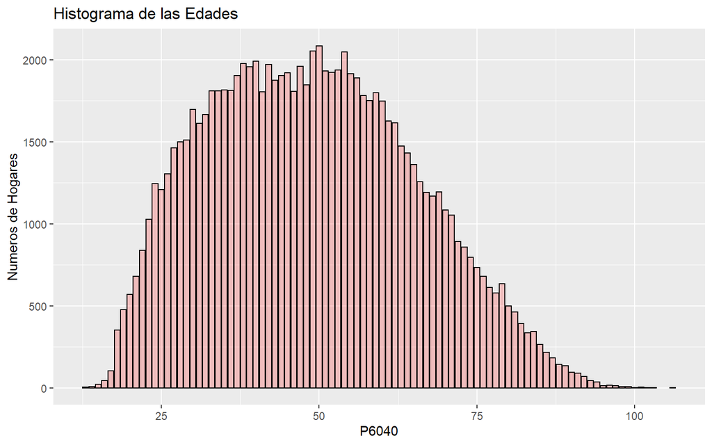

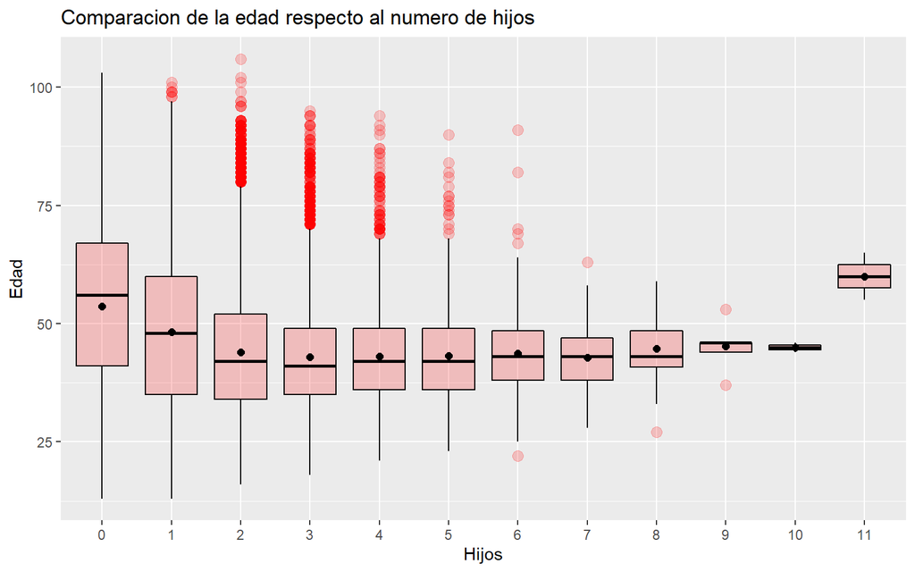

Se observa que los encuestados que tienen **0 hijos** pueden ser determinados por diferentes **edades** a medida que la cantidad de **hijos incrementa** el comportamiento de las **edades** es muy similar.

### Variable Sexo (P6020)

A continuación se muestra el conteo de la variable sexo con $1$ siendo *Hombre* y $2$ siendo *Mujer* mostrando una variable dicotómica con una muestra de mas hombres que mujeres y un total de 93988 encuestados cabeza de hogar. Esta es una variable de las más influyentes según la documentación encontrada ya que muchos sugieren el estudio de la fertilidad de las mujeres para predecir el crecimiento poblacional.

| Sexo | Frecuencia | Frecuencia.Abs. |
| --- | --- | --- |
| 1 | 59880 | 0.6371026 |
| 2 | 34108 | 0.3628974 |

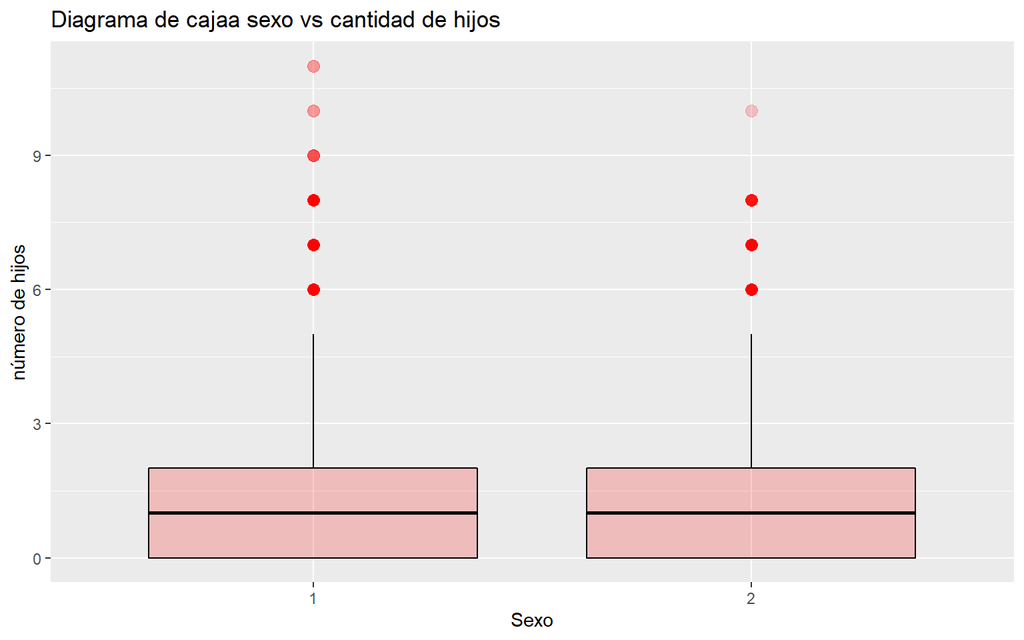

El comportamiento de la cantidad de **hijos** respecto al género del **jefe de hogar** encuestado es muy similar.

### Variable Estado Civil (P5502)

La variable estado civil se refiere a la situación del encuestado por sus relaciones en familia. Es vista como una situación personal, sin embargo, suele sugerir algunos estados económicos de la persona, por lo cual es participativa en la mayoría de las encuestas del estado. Los datos de la encuesta se representan de la siguiente manera:

- $1$ No está casado(a) y vive en pareja hace menos de dos años
- $2$ No está casado(a) y vive en pareja hace dos años o más
- $3$ Está viudo(a)
- $4$ Está separado(a) o divorciado(a)
- $5$ Está soltero(a)
- $6$ Está casado(a)

Se puede ver que aproximadamente el 35% de los encuestados no están casados y viven en pareja hace más de 2 años, además 23% están casados. Artículos como [1] ¿Unión libre o matrimonio? Efectos en el bienestar de los hijos sugieren que el estado civil influye directamente en el bienestar infantil dando a los hogares con padres casados unos mejores resultados en varios aspectos como la estabilidad económica y la planificación a futuro.

[1]: Amador, Diego, & Bernal, Raquel. (2012). ¿Unión libre o matrimonio? Efectos en el bienestar de los hijos. El trimestre económico, 79(315), 529-573. Recuperado en 14 de mayo de 2021, de http://www.scielo.org.mx/scielo.php?script=sci_arttext&pid=S2448-718X2012000300529&lng=es&tlng=es.

| Estado Civil | Frecuencia | Frecuencia.Abs. |
| --- | --- | --- |
| 1 | 2317 | 0.0246521 |
| 2 | 33747 | 0.3590565 |
| 3 | 7963 | 0.0847236 |
| 4 | 16077 | 0.1710538 |
| 5 | 12080 | 0.1285270 |
| 6 | 21804 | 0.2319871 |

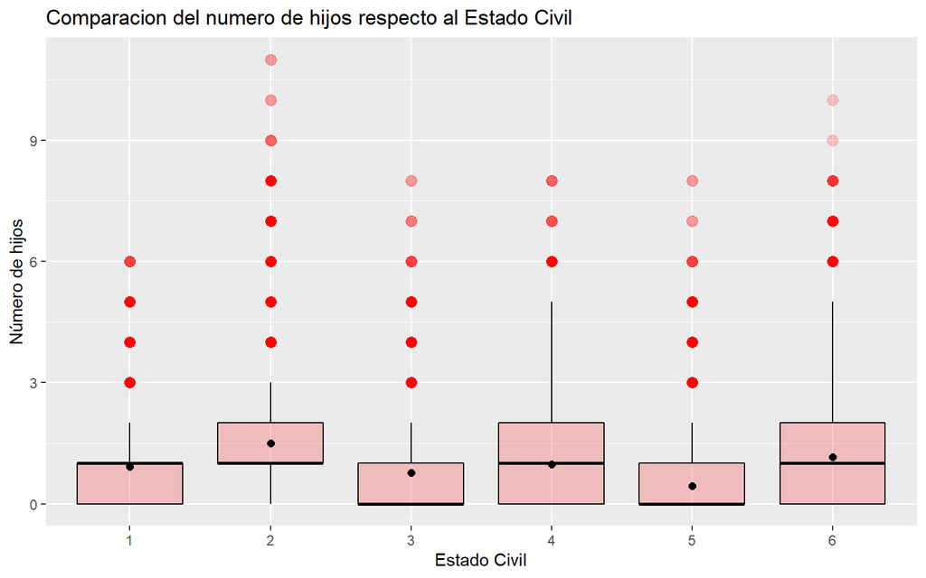

### Variable Etnia (P6080)

La etnia es una caracterización de las comunidades que comparten rasgos socioculturales y afinidades raciales, los miembros de determinados grupos son reconocidos por sus costumbres o creencias, para esta encuesta se tomaron las siguientes etnias:

- $1$ Indígena
- $2$ Gitano(a) (Rom)
- $3$ Raizal del archipiélago de San Andrés, Providencia y Santa Catalina
- $4$ Palenquero (a) de San Basilio
- $5$ Negro (a), mulato (a)(afrodescendiente),afrocolombiano(a)
- $6$ Ninguno de los anteriores

El 80% no pertenecen a ninguna etnia o pueblo específico de alguno de los presentados por la encuesta, además tanto la raza afrodescendiente como la indigena representan un 9% de la muestra. La variable Etnia es considerada importante en este estudio ya que varios autores consideran que las costumbres de las distintas razas pueden influir en la estructuración de las familias de las futuras generaciones.

| Etnia | Frecuencia | Frecuencia.Abs. |
| --- | --- | --- |
| 1 | 8875 | 0.0944269 |
| 2 | 38 | 0.0004043 |
| 3 | 309 | 0.0032877 |
| 4 | 54 | 0.0005745 |
| 5 | 9168 | 0.0975444 |
| 6 | 75544 | 0.8037622 |

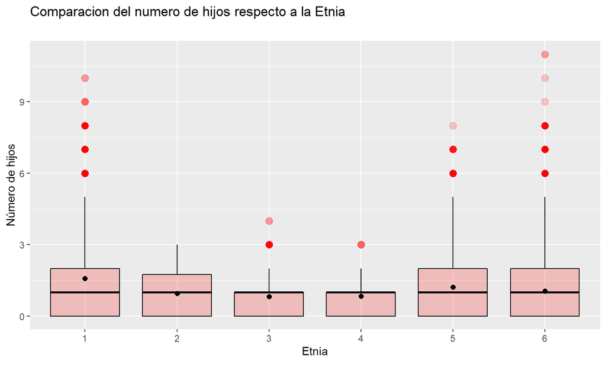

### Variable Región (REGION)

Pregunta relacionada a la región en que se encuentra el hogar de la persona encuestada, donde:

- $1$ Caribe
- $2$ Oriental
- $3$ Central
- $4$ Pacifica(sin valle)
- $5$ Bogota
- $6$ Antioquia
- $7$ Valle del Cauca
- $8$ San Andrés
- $9$ Orinoquía - Amazonía

Se puede ver que la región con mayor cantidad de encuestados pertenece a la región $Caribe$ seguido por la región $Central$, además, las regiones con menos encuestados son $San Andrés$ y $Bogotá$. Según indicadores del banco mundial [2] la tasa de natalidad va en decrecimiento cada año sin embargo para cada país la cantidad de nacidos vivos por cada mil personas cambia . Así mismo, al tener una mayor cantidad de encuestados por region es posible que la cantidad de hijos para esa región sea mayor.

[2]: Banco Mundial. (2019). Tasa de natalidad, nacidos vivos en un año (por cada 1.000 personas), de https://datos.bancomundial.org/

| Region | Frecuencia | Frecuencia.Abs. |
| --- | --- | --- |
| 1 | 21326 | 0.2269013 |
| 2 | 16698 | 0.1776610 |
| 3 | 20260 | 0.2155594 |
| 4 | 9125 | 0.0970869 |
| 5 | 2072 | 0.0220454 |
| 6 | 3669 | 0.0390369 |
| 7 | 3231 | 0.0343767 |
| 8 | 1230 | 0.0130868 |
| 9 | 16377 | 0.1742456 |

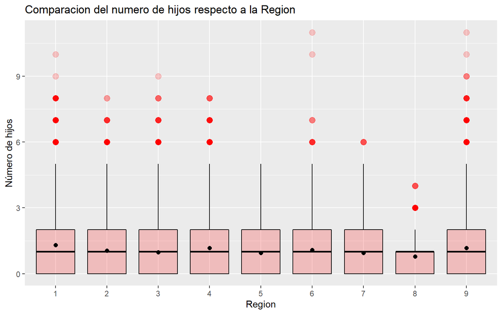

### Variable Estrato (P8520S1A1)

Pregunta relacionada con el estrato en que se encuentra el hogar de la persona encuestada, basado en la información presentada por el recibo de servicios públicos de energía eléctrica, donde:

- $0$ Recibos sin estrato o el servicio es pirata
- $1$ Bajo - Bajo
- $2$ Bajo
- $3$ Medio - Bajo
- $4$ Medio
- $5$ Medio - Alto
- $6$ Alto
- $8$ Planta eléctrica
- $9$ No conoce el estrato o no cuenta con recibo de pago.

Nótese que los valores categóricos de nivel se encuentran entre 0−6, mientras que los valores $8$ y $9$ se refieren al uso de una planta eléctrica o el desconocimiento de la información. Por otro lado se puede ver que la mayoría de encuestados pertenecen a los estratos bajo−bajo y bajo según el recibo de servicios públicos indicando que más del $70\%$ pertenecen a estratos $2$ o menor.

| Estrato | Frecuencia | Frecuencia.Abs. |
| --- | --- | --- |
| 0 | 3999 | 0.0450368 |
| 1 | 45058 | 0.5074442 |
| 2 | 23620 | 0.2660090 |
| 3 | 7960 | 0.0896457 |
| 4 | 2420 | 0.0272541 |
| 5 | 1147 | 0.0129175 |
| 6 | 700 | 0.0078834 |
| 8 | 2005 | 0.0225804 |
| 9 | 1885 | 0.0212289 |

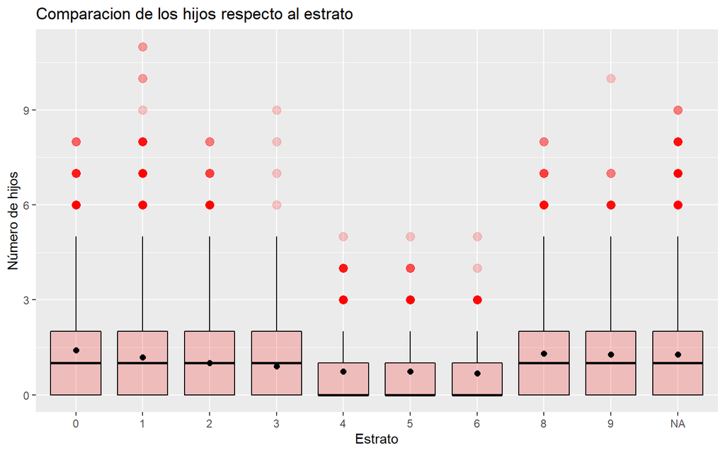

### Variable Nivel Educativo (P8587)

Pregunta relacionada al nivel educativo más alto alcanzado por la cabeza del hogar y el último año o grado aprobado en este nivel, donde;

- $1$ Ninguno
- $2$ Preescolar
- $3$ Básica Primaria $(1º - 5º)$
- $4$ Básica secundaria $(6º-9º)$
- $5$ Media $(10º-13º)$
- $6$ Técnico sin título
- $7$ Técnico con título
- $8$ Tecnológico sin título
- $9$ Tecnológico con título
- $10$Universitario sin titulo
- $11$Universitario con titulo
- $12$Postgrado sin titulo
- $13$ Postgrado con titulo

Los valores $3$,$4$ y $5$ corresponden a más del $70\%$ de la población, encontrándose un nivel educativo promedio en básica secundaria, y media. La variable resulta interesante para el estudio pues según Medina Hernández, Edith Johana. (2012) [3] la educación y la fecundidad de las mujeres están estrechamente ligadas, mostrando que altos niveles de educación en las mujeres disminuyen la fecundidad.

[3]: Medina Hernández, Edith Johana. (2012). Diferenciales regionales de la fecundidad según el nivel educativo de las mujeres colombianas en edad fértil. Sociedad y Economía, (23), 205-234. Retrieved May 14, 2021, from http://www.scielo.org.co/scielo.php?script=sci_arttext&pid=S1657-63572012000200011&lng=en&tlng=es

| Nivel Educación | Frecuencia | Frecuencia.Abs. |
| --- | --- | --- |
| 1 | 8603 | 0.0938956 |
| 10 | 779 | 0.0085022 |
| 11 | 5536 | 0.0604215 |
| 12 | 60 | 0.0006549 |
| 13 | 1780 | 0.0194274 |
| 3 | 36758 | 0.4011875 |
| 4 | 12350 | 0.1347915 |
| 5 | 18845 | 0.2056798 |
| 6 | 297 | 0.0032415 |
| 7 | 4721 | 0.0515264 |
| 8 | 135 | 0.0014734 |
| 9 | 1759 | 0.0191982 |

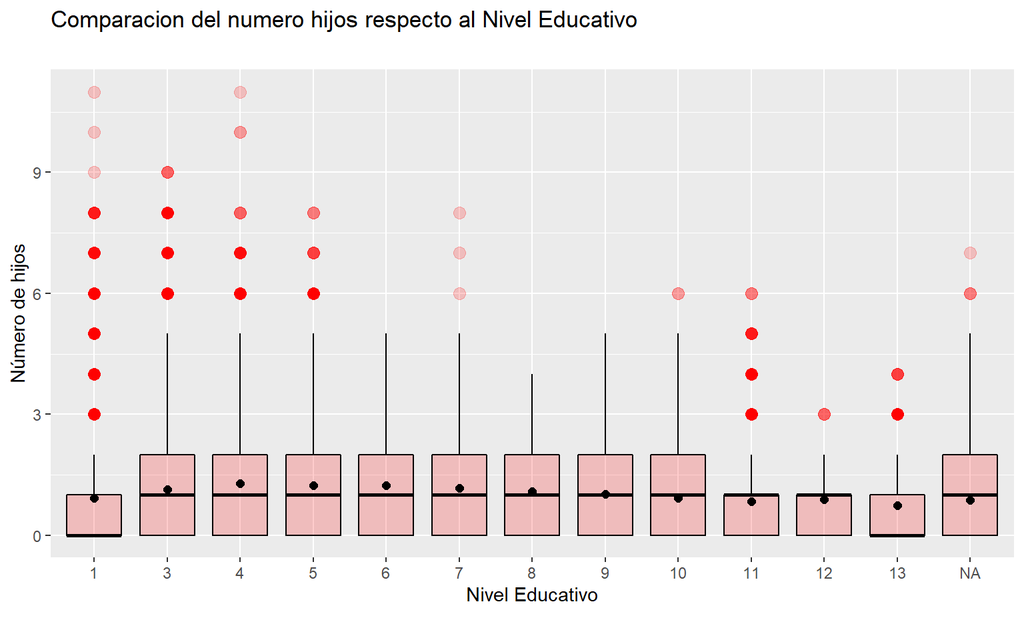

### Algunas graficas Descriptivas de Interes

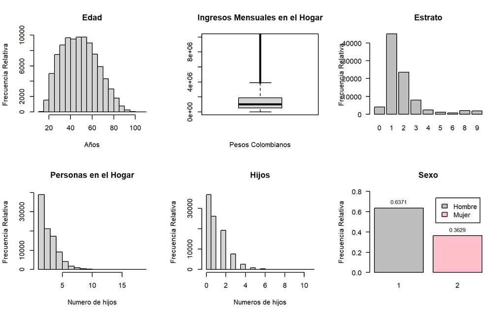

## Relaciones entre las variables y nuestra etiqueta (Hijos)

Variables Categóricas:

[figure not shown]

No se alcanza a percibir algún tipo de relación en el grafico anterior.

Variables Continuas:

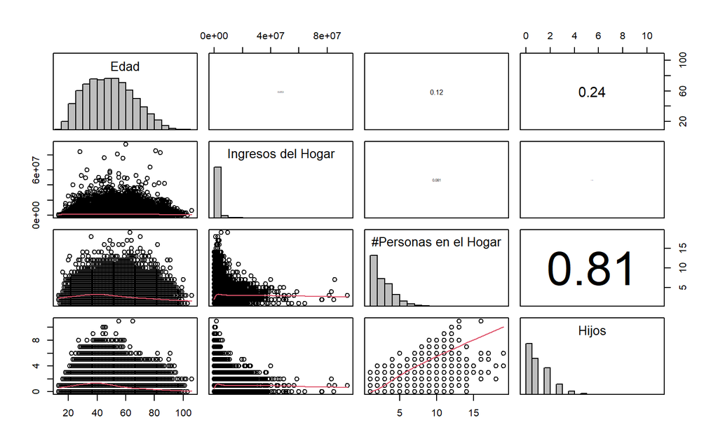

Se observan una posible relación fuerte entre el **Número de personas en el hogar** y la variable hijo. Dicha relación es un poco **obvia**.

| Correlación de las Personas del Hogar entre el Número de Hijos |
| --- |
| 0.8095036 |

Efectivamente dichas variables están relacionadas.

# Modelo de regresión utilizando KNN

El método de KNN, aunque utilizado generalmente para problemas de clasificación, puede ser también usado para casos de regresión. KNN utiliza las características de sus K vecinos más cercanos para hacer una predicción.

## Importe de librería para el modelo de regresión

```r
# Caret para el modelo
library(caret)
# Para entrenar el modelo con multithreading
library(parallel)
library(doParallel)
library(kableExtra)
```

## Muestreo y separación en entrenamiento y validación

Se fija la semilla generadora de números aleatorios para garantizar la reproducibilidad de los resultados.

Adicionalmente, se separa el marco de datos en datos de entrenamiento y datos de validación o prueba. La proporción utilizada fue de $0.8$ para entrenamiento y $0.2$ para validación.

```r
# Semilla para generación de números aleatorios
set.seed(20210406)
# Asignación de índices del dataset para training 0.8 y testing 0.2
indexTraining <- createDataPartition(y = clean_labeled_input$HIJOS, p = 0.8, list = FALSE)
# Parte del dataset designada para training
train <- clean_labeled_input[indexTraining,]
# Parte del dataset designada para testing
test <- clean_labeled_input[-indexTraining,]
```

## Preprocesamiento

Adicional al preprocesamiento realizado anteriormente para la obtención del conjunto de datos inicial, se realiza un pre-procesamiento específico al modelo KNN. Debido a que KNN es muy sensible a la distancia entre los datos y las unidades de estos, es necesario normalizar los datos antes de entrenar el modelo. El paquete `caret` hace este paso de normalización por nosotros, como una de las opciones a la hora de entrenar el modelo.

Debido a que se tiene una cantidad significativa de datos $(93.993)$, se decide no hacer imputación de datos, y en cambio, omitir los valores que contengan información incompleta.

## Entrenamiento y control

```r
# Guardamos el modelo
saveRDS(knn_fit, '../shiny/data/knnModel.rds')
```

[output not shown]

Veamos qué valor de K obtuvo mejores resultados.

```r
# veamos cuál valor de K fue seleccionado como el mejor
knitr::kable(knn_fit$results) %>% kable_paper()
```

| k | RMSE | Rsquared | MAE | RMSESD | RsquaredSD | MAESD |
| --- | --- | --- | --- | --- | --- | --- |
| 5 | 0.7033403 | 0.6403168 | 0.4536405 | 0.0115070 | 0.0095872 | 0.0059083 |
| 7 | 0.6998452 | 0.6440311 | 0.4627291 | 0.0106582 | 0.0090780 | 0.0053483 |
| 9 | 0.7016986 | 0.6432146 | 0.4714937 | 0.0089750 | 0.0080383 | 0.0042463 |
| 11 | 0.7032640 | 0.6430812 | 0.4785081 | 0.0086768 | 0.0078996 | 0.0044515 |
| 13 | 0.7070156 | 0.6406867 | 0.4853028 | 0.0089781 | 0.0082077 | 0.0047041 |

Según la optimización de parámetros, el mejor modelo es aquel con un valor de $K = 7$, pues obtuvo el menor RMSE y el mejor puntaje R2.

```r
# Veamos solamente el modelo seleccionado
knitr::kable(knn_fit$results[2,]) %>% kable_paper()
```

|  | k | RMSE | Rsquared | MAE | RMSESD | RsquaredSD | MAESD |
| --- | --- | --- | --- | --- | --- | --- | --- |
| 2 | 7 | 0.6998452 | 0.6440311 | 0.4627291 | 0.0106582 | 0.009078 | 0.0053483 |

## Validación y pruebas

Se utiliza el conjunto de prueba para comprobar la validez del modelo y se visualiza su desempeño con los valores RMSE y R2.

```r
# Probamos el modelo con el conjunto de prueba
test_pred <- predict(knn_fit, newdata = test, na.action = na.omit)
```

### Medidas de desempeño

Principalmente, se utilizaron dos métricas para evaluar el desempeño del modelo.

#### RMSE (Raíz del error cuadrático medio)

El RMSE del modelo para el conjunto de pruebas es el siguiente:

```r
test_clean <- na.omit(test)
rmseVal <- RMSE(pred = test_pred, obs = test_clean$HIJOS)
```

Este valor mide la cantidad de error que hay entre el valor predicho y el valor conocido.

#### Coeficiente R2

El Coeficiente R2 para el conjunto de pruebas es el siguiente:

```r
r2Val <- R2(pred = test_pred, obs = test_clean$HIJOS)
```

```r
metricas <- as.data.frame(cbind(rmseVal, r2Val))
colnames(metricas) <- c("RMSE", "Valor R2")
knitr::kable(metricas) %>% kable_paper()
```

| RMSE | Valor R2 |
| --- | --- |
| 0.7004439 | 0.644326 |

Este coeficiente representa la proporción de varianza en los resultados que nuestro modelo es capaz de explicar y nos da información sobre qué tan bien se ajusta el modelo a los datos [7].

# Observaciones

- Una de las consideraciones más importantes al momento de desarrollar el modelo, fue la selección de variables, a pesar de realizar búsquedas en diferentes fuentes de información que dieran indicios de las variables influyentes en el número de hijos en un hogar, al momento de probar las correlaciones se encontraba que muchas de ellas no influían en la variable objetivo. Según [3] factores como la educación y la riqueza eran variables relacionadas con la fertilidad de la población; sin embargo, aun son necesarios más estudios para establecer la causalidad y la importancia relativa de estas variables.
- El método de KNN a mayor cantidad de variables suele tener dificultades con la predicción debido a la cantidad de distancias que debe considerar para tomar la decisión adecuada. Esta puede ser una de las razones del valor del RMSE.
- La identificación de datos atípicos en la base de datos es fundamental para evitar obtener estadísticos que no representen adecuadamente la muestra.
- Es importante la simplificación del modelo y la cantidad de variables usadas para reducir el costo computacional.
- En cuanto, a la validación de los modelos, se hizo uso de las medidas de bondad de ajuste error cuadrático medio RMSE y el R-cuadrado. De esta manera, se observa que el modelo con mejor ajuste es el modelo con $K=7$. Así, el RMSE de este modelo es de $0.6998452$ tiene un valor relativamente bajo en comparación con los otros modelos, asimismo, se evidencia una r-cuadrada de 0.6440311 lo que permite concluir que las variables predictoras incluidas en el modelo predicen el $64,40%$ de las predicciones en la cantidad de hijos en el hogar.

[1]

DANE, “Encuesta Nacional de Calidad de Vida 2019.” 2020 [Online]. Available: http://microdatos.dane.gov.co/index.php/catalog/678/study-description. [Accessed: 31-Mar-2021]

[2]

C. E. Flórez and L. M. Sánchez, *Fecundidad y familia en Colombia: ¿hacia una segunda transición demográfica?*, vol. 9. 2013, p. 60.

[3]

F. Götmark and M. Andersson, “Human fertility in relation to education, economy, religion, contraception, and family planning programs,” *BMC public health*, vol. 20, no. 1, p. 265, 2020, doi: 10.1186/s12889-020-8331-7.

[4]

D. Amador, R. Bernal, and X. Peña, “Aumento de la participación femenina en Colombia: ¿fecundidad, estado civil o educación? The rise in female participation in Colombia: Fertility, marital status or education?” vol. 31, pp. 54–63, 2013 [Online]. Available: http://www.scielo.org.co/pdf/espe/v31n71/v31n71a3.pdf

[5]

E. Robayo, “TIPOLOGÍAS DEL HOGAR EN COLOMBIA (2000-2015): CARACTERISTICAS SOCIODEMOGRAFICAS DE LAS MUJERES,” *Entrevistas*, pp. 5–6, 2019.

[6]

A.-M. Gómez-Sánchez, C.-L. Fajardo-Hoyos, and J.-I. Sarmiento-Castillo, “Composición de los hogares y niveles de gastos en bienes y servicios básicos en el Departamento del Cauca, Colombia,” *Semestre Económico*, vol. 18, no. 38, pp. 67–104, 2015, doi: 10.22395/seec.v18n38a3.

[7]

“Coefficient of Determination,” in *The concise encyclopedia of statistics*, New York, NY: Springer New York, 2008, pp. 88–91 [Online]. Available: https://doi.org/10.1007/978-0-387-32833-1_62